# 05-quantile-errors

## Data Science 5620 — Deliverable 05

### Rastko Stojsin

#### Which quantiles of a continuous distribution can one estimate with more precision?

The median is an important quantity in data analysis. It represents the middle value of the data distribution. Estimates of the median, however, have a degree of uncertainty because (a) the estimates are calculated from a finite sample and (b) the data distribution of the underlying data is generally unknown. One important roles of a data scientist is to quantify and to communicate the degree of uncertainty in his or her data analysis.

Below we show the sampling distribution for the quantiles is generated by repeatedly calculating the quantiles from random samples of size 200 and calculating the length of the middle 95% of the sampling distribution. The empirical sampling distribution is 5000 draws.

### Distribution 1: standard normal distribution

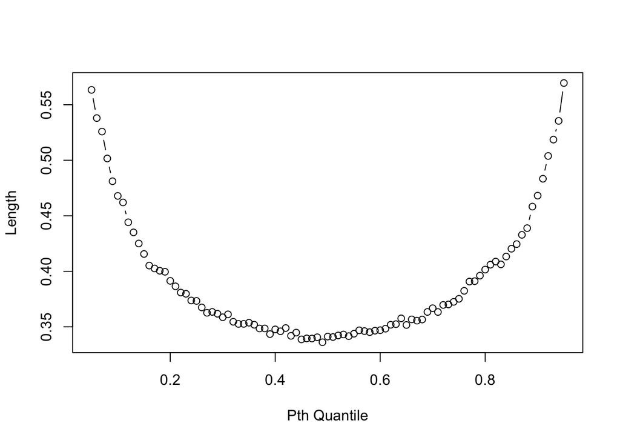

```r
mid.length <- apply(rand_sample_grid, 2, function(x) quantile(x,0.975)-quantile(x, 0.025))
plot(seq(0.05,0.95,by=0.01), mid.length, type='b', xlab = 'Pth Quantile', ylab = 'Length')
```

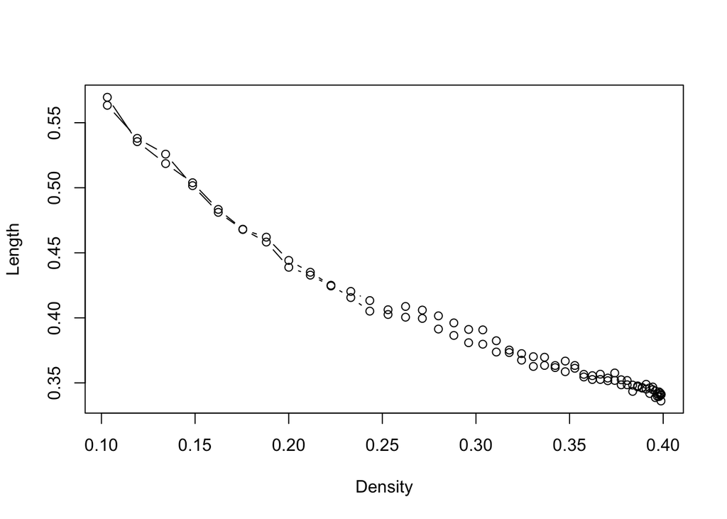

```r
plot(dnorm(qnorm(seq(0.05,0.95,by=0.01))), mid.length, type = 'b', xlab = 'Density', ylab = 'Length')
```

The lengths of the 95% confidence intervals are shortest at/near the mean/median and the longest at the tail ends of the distribution. We can see that the higher the higher density is at any quantile - the smaller the length of the 95% confidence interval. The standard normal distribution is most dense near the median and least dense by the tails.

### Distribution 2: exponential distribution (rate of 1)

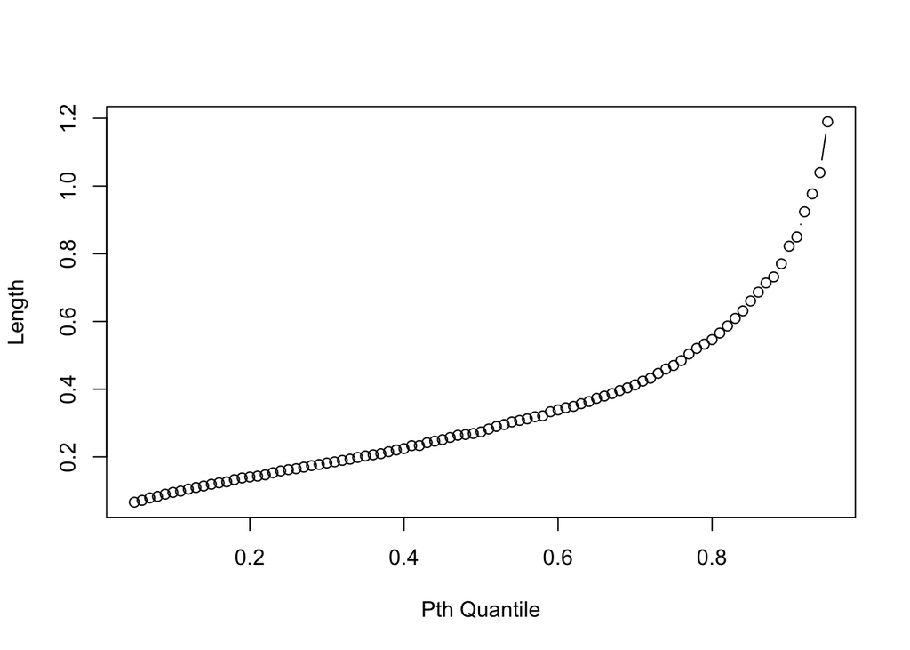

```r
mid.length <- apply(rand_sample_grid, 2, function(x) quantile(x,0.975)-quantile(x, 0.025))
plot(seq(0.05,0.95,by=0.01), mid.length, type = 'b', xlab = 'Pth Quantile', ylab = 'Length')
```

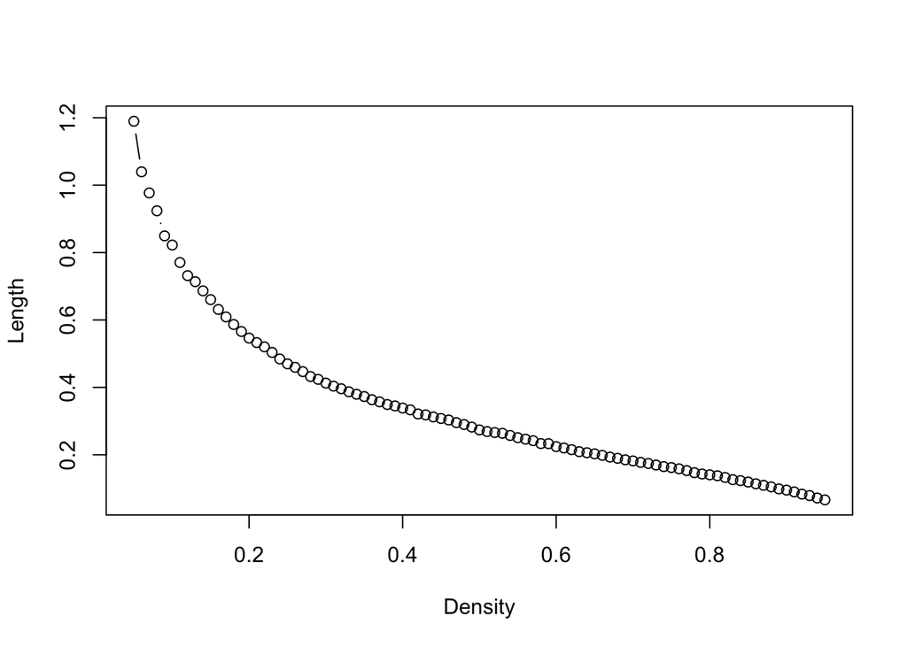

```r
plot(dexp(qexp(seq(0.05,0.95,by=0.01))), mid.length, type = 'b', xlab = 'Density', ylab = 'Length')
```

Agian the areas with the highest density have the smallest CI length. Meaning in an exponencial function the points near the begining (0) have the smallest length of confidence interval.

### Distribution 3: mixed distribution shown below

```r
# f3 distribution
rf3 <- function(N){
  G <- sample(0:2, N, replace = TRUE, prob = c(5,3,2))
  (G==0)*rnorm(N) + (G==1)*rnorm(N,4) + (G==2)*rnorm(N,-4,2)
}
pf3 <- function(x){
  .5*pnorm(x) + .3*pnorm(x,4) + .2*pnorm(x,-4,2)
}
df3 <- function(x){
  .5*dnorm(x) + .3*dnorm(x,4) + .2*dnorm(x,-4,2)
}

g <- function(x,pf,p) pf(x) - p

qf3 <- function(p){
  out <- p
  for(i in seq_along(p)){
    out[i] <- uniroot(g, c(-100,100), pf = pf3, p = p[i])$root
  }
  out
}
```

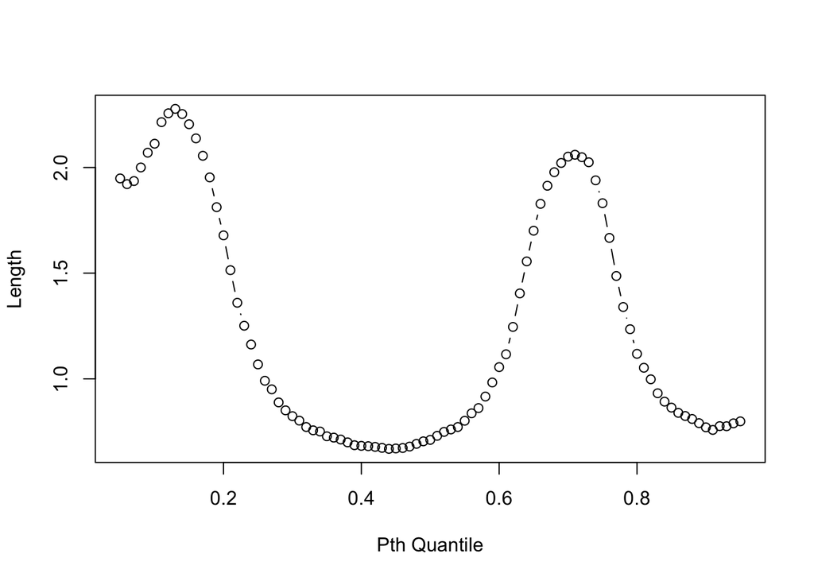

```r
mid.length <- apply(rand_sample_grid, 2, function(x) quantile(x,0.975)-quantile(x, 0.025))
plot(seq(0.05,0.95,by=0.01), mid.length, type = 'b', xlab = 'Pth Quantile', ylab = 'Length')
```

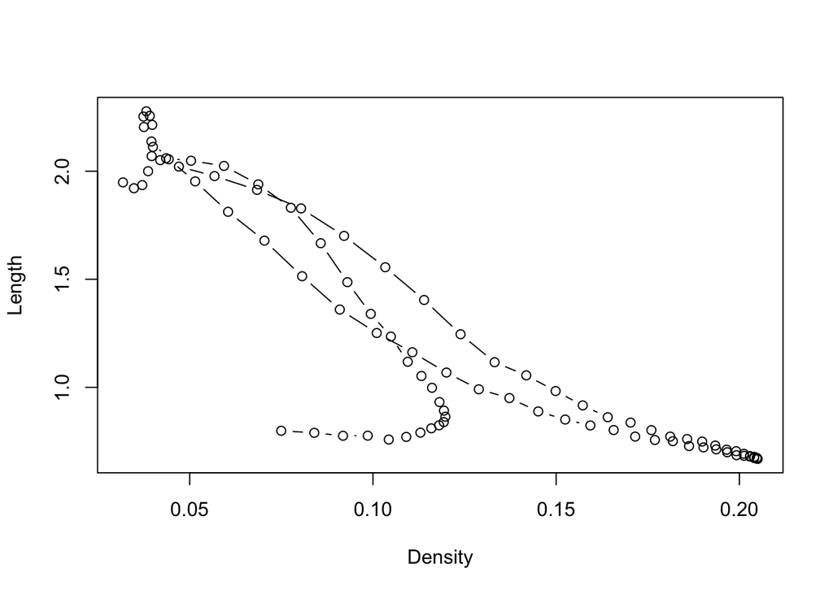

```r
plot(df3(qf3(seq(0.05,0.95,by=0.01))), mid.length, type = 'b',  xlab = 'Density', ylab = 'Length')
```

In this mixed distribution there are two areas with relativly low length of 95% confidence interval. One at just below the median (that has the highest density), and one at the right tail of the distribution (which also has a relativly high density).

### Distribution 4: mixed distribution shown below

```r
# f4 distribution
rf4 <- function(N){
  G <- sample(0:1, N, replace = TRUE)
  (G==0)*rbeta(N,5,1) + (G==1)*rbeta(N,1,5)
}
pf4 <- function(x) .5*pbeta(x,5,1) + .5*pbeta(x,1,5)
df4 <- function(x) .5*dbeta(x,5,1) + .5*dbeta(x,1,5)
qf4 <- function(p){
  out <- p
  for(i in seq_along(p)){
    out[i] <- uniroot(g, c(0,1), pf = pf4, p = p[i])$root
  }
  out
}
```

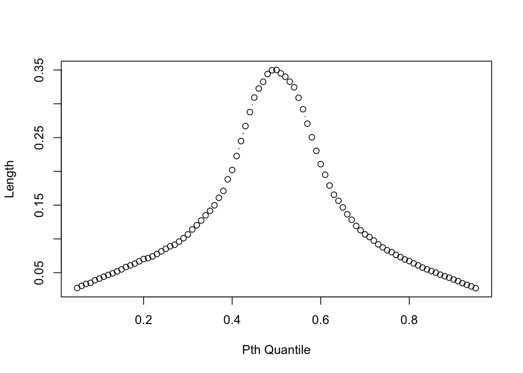

```r
mid.length <- apply(rand_sample_grid, 2, function(x) quantile(x,0.975)-quantile(x, 0.025))
plot(seq(0.05,0.95,by=0.01), mid.length, type = 'b', xlab = 'Pth Quantile', ylab = 'Length')
```

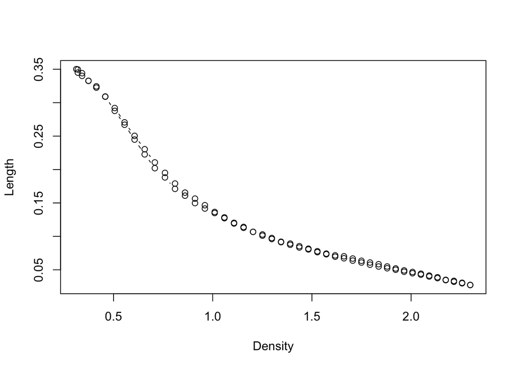

```r
plot(df4(qf4(seq(0.05,0.95,by=0.01))), mid.length, type = 'b',  xlab = 'Density', ylab = 'Length')
```

This one is interesting because although our properties of - high density = high percision (low length of 95% condifence interval), The distribution is almost an inverse of the standard normal. The area around the median is the least dense area - with higher desity and thus more percise (95% confidence interval) areas near the tails.